# Etude statistique de la fréquence

Noureddine Oulid-Azouz, Margaux Regnault

Certain montants de sinistres sont négatifs : on les exclut de la base et on ne modélise alors que les montants bruts de recours. Des clients peuvent avoir plusieurs sinsitres sur le même contrat dans la même année : pour l’étude statistique de la fréquence, on somme le nombre de sinistres par client.

### Description des données

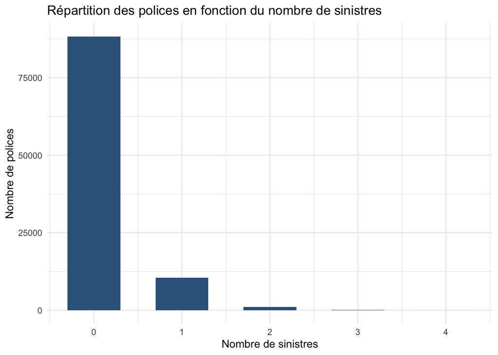

| claim_nb | nombre | pourcentage |
| --- | --- | --- |
| 0 | 88273 | 88.273 |
| 1 | 10541 | 10.541 |
| 2 | 1080 | 1.080 |
| 3 | 101 | 0.101 |
| 4 | 5 | 0.005 |

|  | claim_nb | drv_age1 | drv_age_lic1 | vh_age | vh_cyl | vh_din | vh_speed | vh_value | vh_weight | pol_bonus | pol_duration |
| --- | --- | --- | --- | --- | --- | --- | --- | --- | --- | --- | --- |
|  | Min. :0.0000 | Min. : 19.00 | Min. : 0.00 | Min. : 1.000 | Min. : 0 | Min. : 15.00 | Min. : 75.0 | Min. : 0 | Min. : 0 | Min. :0.5000 | Min. : 1.00 |
|  | 1st Qu.:0.0000 | 1st Qu.: 43.00 | 1st Qu.:23.00 | 1st Qu.: 4.000 | 1st Qu.:1360 | 1st Qu.: 68.00 | 1st Qu.:157.0 | 1st Qu.: 11950 | 1st Qu.: 950 | 1st Qu.:0.5000 | 1st Qu.: 4.00 |
|  | Median :0.0000 | Median : 54.00 | Median :32.00 | Median : 8.000 | Median :1587 | Median : 87.00 | Median :170.0 | Median : 16200 | Median :1125 | Median :0.5000 | Median : 9.00 |
|  | Mean :0.1302 | Mean : 54.61 | Mean :32.35 | Mean : 9.481 | Mean :1643 | Mean : 91.32 | Mean :170.7 | Mean : 18037 | Mean :1127 | Mean :0.5377 | Mean :11.09 |
|  | 3rd Qu.:0.0000 | 3rd Qu.: 65.00 | 3rd Qu.:41.00 | 3rd Qu.:13.000 | 3rd Qu.:1905 | 3rd Qu.:109.00 | 3rd Qu.:185.0 | 3rd Qu.: 22106 | 3rd Qu.:1320 | 3rd Qu.:0.5000 | 3rd Qu.:16.00 |
|  | Max. :4.0000 | Max. :103.00 | Max. :73.00 | Max. :63.000 | Max. :6997 | Max. :507.00 | Max. :310.0 | Max. :155498 | Max. :7901 | Max. :1.6500 | Max. :40.00 |

| pol_coverage | somme |
| --- | --- |
| Maxi | 64623 |
| Median2 | 17401 |
| Median1 | 9404 |
| Mini | 8572 |

| vh_make | somme |
| --- | --- |
| RENAULT | 27011 |
| PEUGEOT | 19278 |
| CITROEN | 15800 |
| VOLKSWAGEN | 5456 |
| FORD | 4473 |
| OPEL | 3709 |
| TOYOTA | 3290 |
| MERCEDES BENZ | 3081 |
| FIAT | 2817 |
| NISSAN | 1750 |

| vh_fuel | somme |
| --- | --- |
| Diesel | 54760 |
| Gasoline | 45160 |
| Hybrid | 80 |

| vh_type | somme |
| --- | --- |
| Tourism | 90305 |
| Commercial | 9695 |

| pol_usage | somme |
| --- | --- |
| WorkPrivate | 66055 |
| Retired | 26655 |
| Professional | 7195 |
| AllTrips | 95 |

| pol_region | somme |
| --- | --- |
| Ile-de-France | 15621 |
| Auvergne-Rhône-Alpes | 13270 |
| Nouvelle-Aquitaine | 11323 |
| Grand Est | 9875 |
| Occitanie | 9024 |
| Hauts-de-France | 8933 |
| Provence-Alpes-Côte d’Azur | 7408 |
| Pays de la Loire | 7006 |
| Bretagne | 5542 |
| Bourgogne-Franche-Comté | 4064 |
| Normandie | 3837 |
| Centre-Val de Loire | 3750 |
| Corse | 347 |

### Matrices de corrélation

Les variables suivantes sont retenues.

Pour la police :

- pol_coverage
- pol_bonus
- pol_duration
- pol_usage
- pol_region
- drv_age1
- drv_age_lic1

Pour le véhicule :

- vh_age
- vh_cyl
- vh_din
- vh_fuel
- vh_make
- vh_speed
- vh_type
- vh_value
- vh_weight
- vh_type

Pour les variables numériques, l’étude des corrélations permet de faire une première sélection pour la suite de l’analyse. Nous utilisons la corrélation de Pearson.

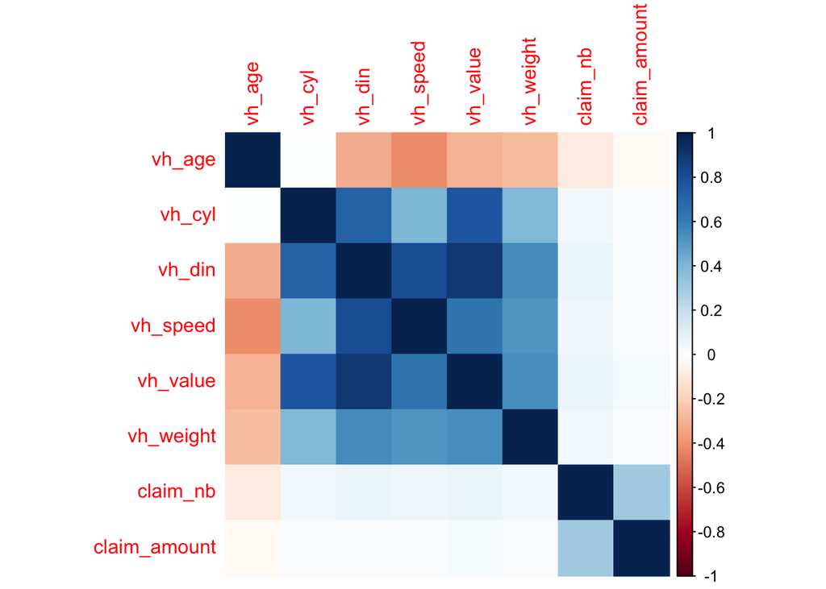

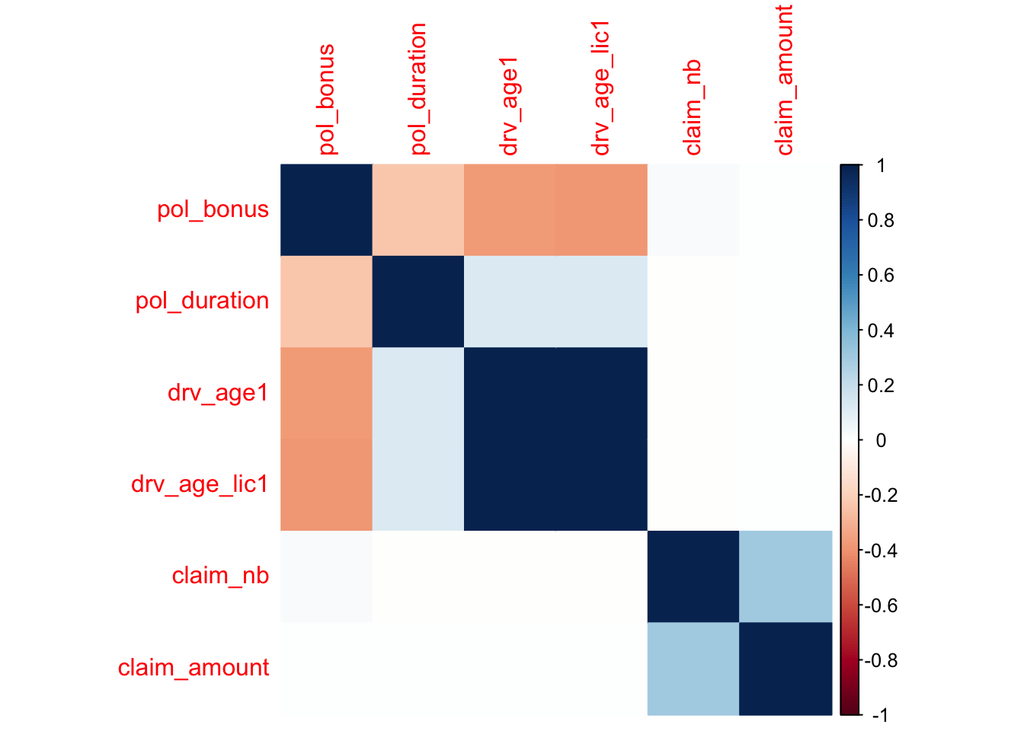

##### Variables sélectionnées

Variables numériques :

- vh_age
- vh_value
- vh_din
- pol_bonus
- pol_duration
- drv_age1

Variables catégorielles :

- vh_fuel
- vh_make
- pol_coverage
- pol_usage
- pol_region

### Statistiques autour de la police et du conducteur

Cette partie de visualisation statistique permet d’observer les éventuels liens entre nos variables et la fréquence. Elle permet également de construire des classes de risques homogènes pour chacune des variables. La légende des abscisses de certains graphiques se sont pas lisibles mais ces derniers permettent la construction de classes pertinentes.

##### Âge du conducteur

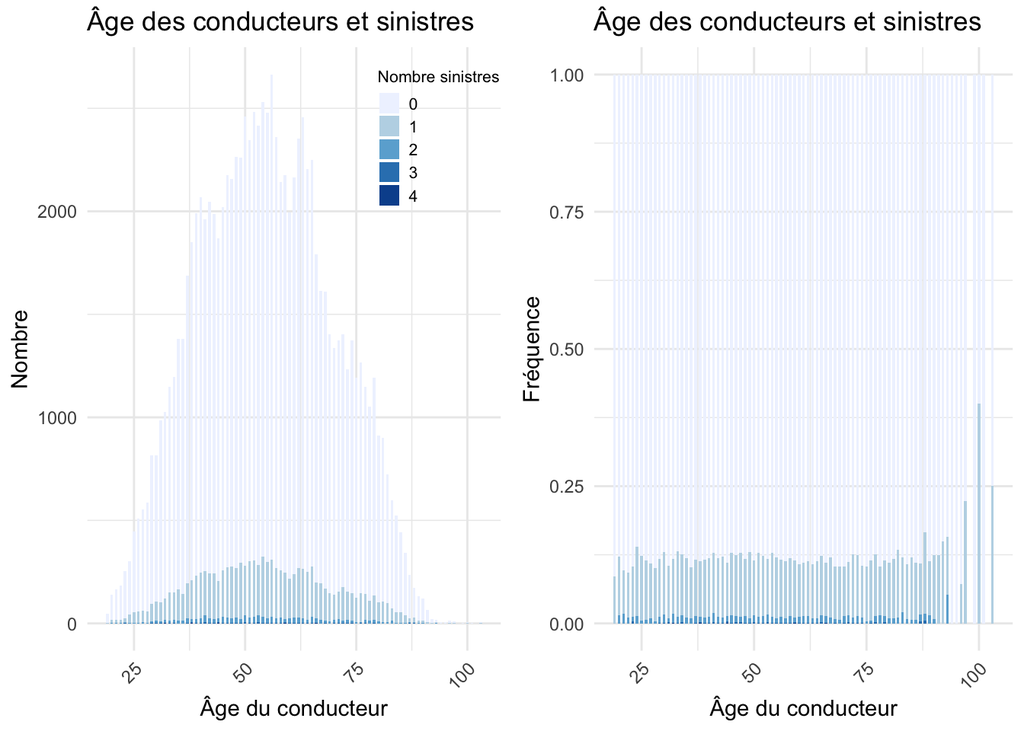

Aucune tendance générale ne se dessine, la variable de l’âge du conducteur sera dans la suite considérée par intervalles de 5 ans.

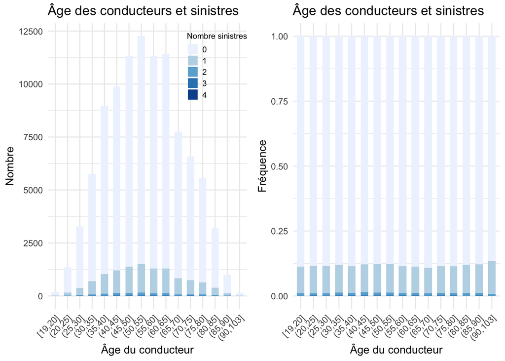

##### Durée de la police

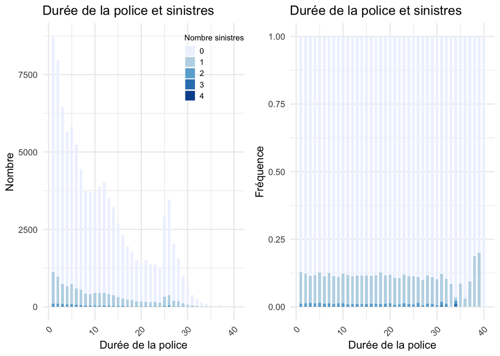

La fréquence de sinistres est légèrement décroissante avec la durée de la police, des classes de 5 ans sont construites.

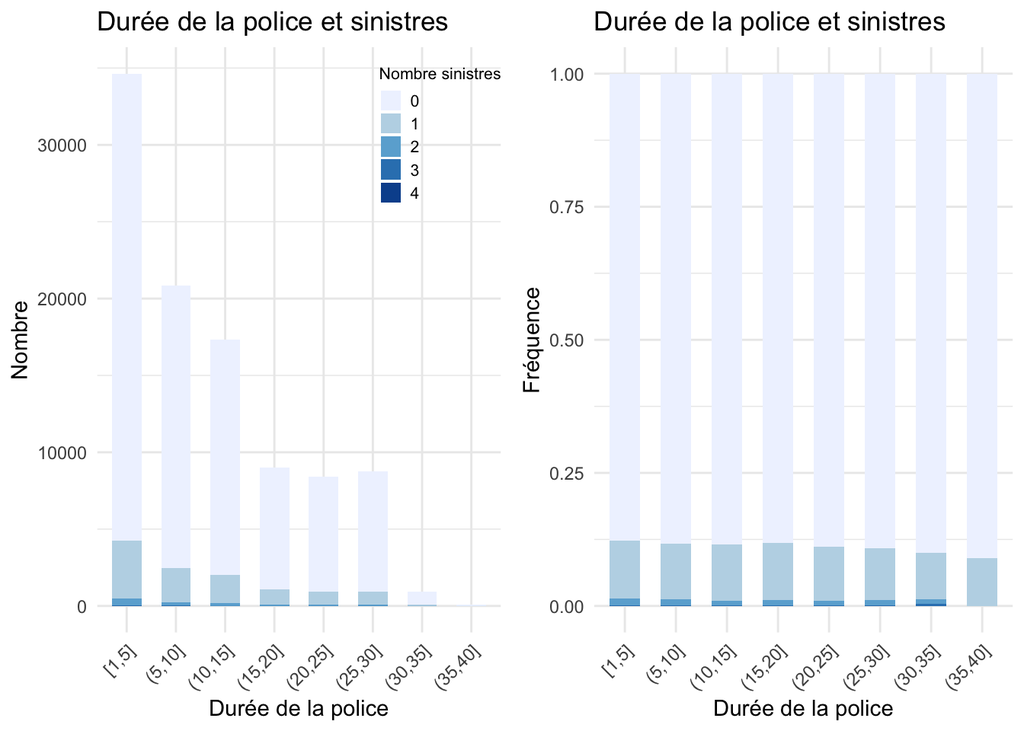

##### Bonus

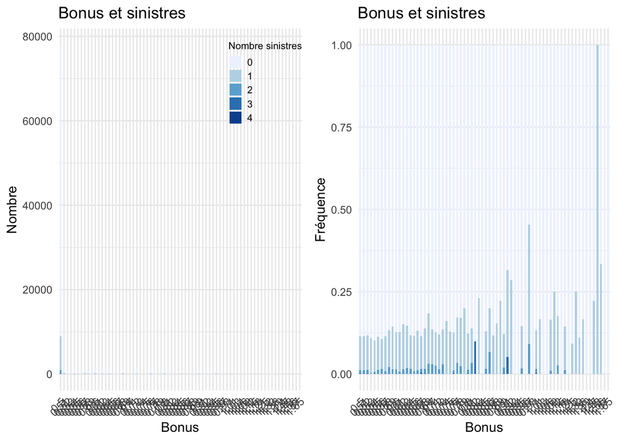

Les bonus sont regroupés selon des classes d’invertalle 0,1.

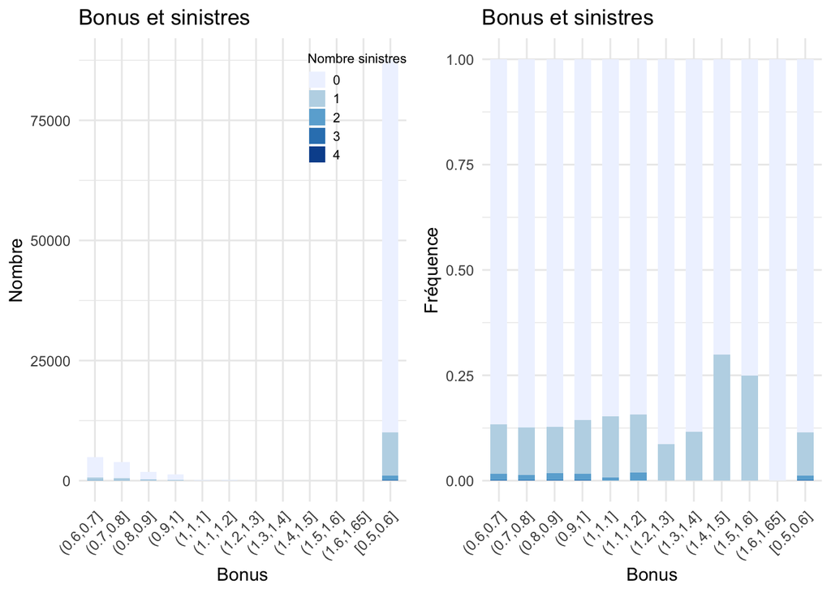

##### Couverture

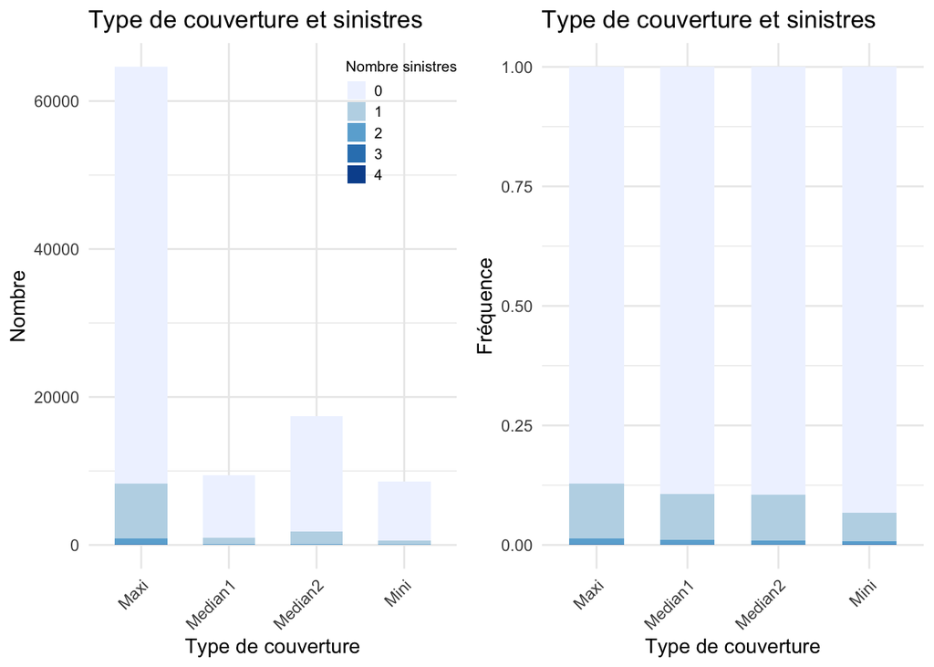

Dans la suite, on regroupe les catégories Median1 et Median2 dans une seule catégorie.

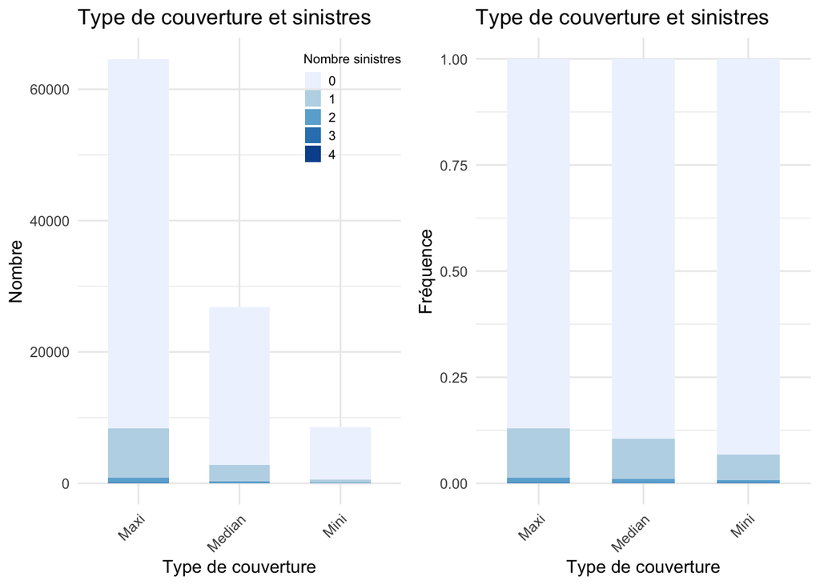

##### Usage de la police

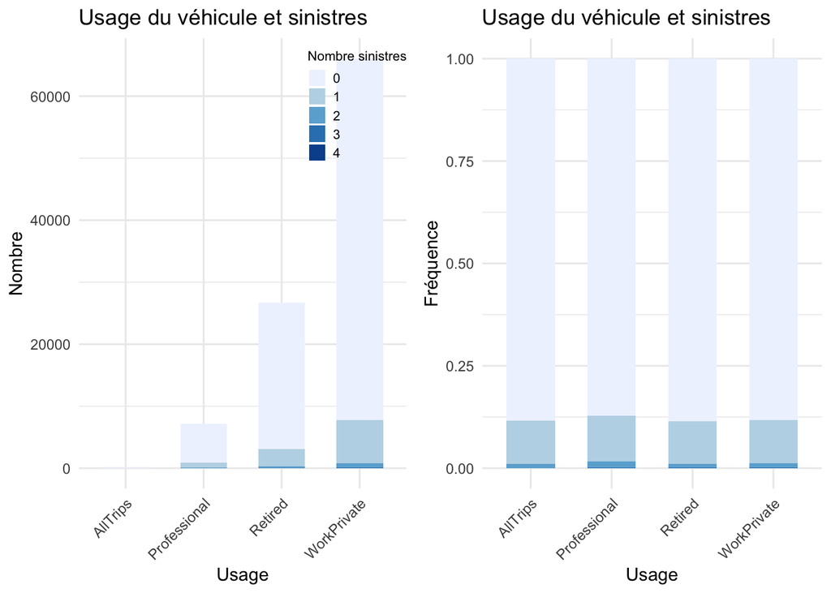

Nous ne distinguons plus que la catégorie Professional.

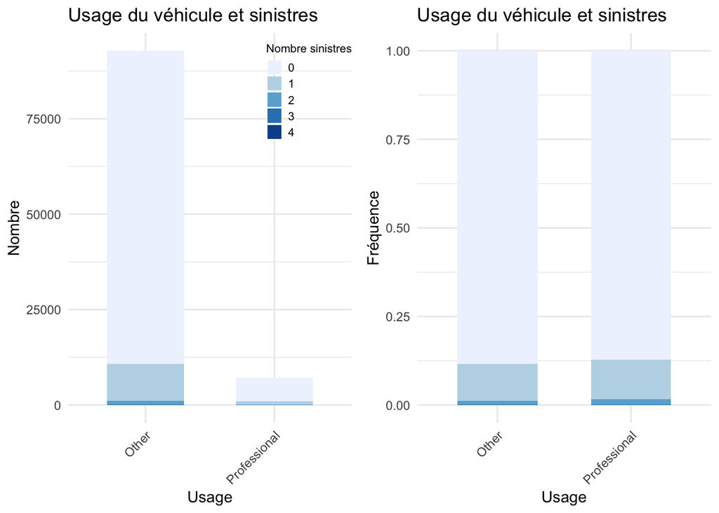

##### Régions

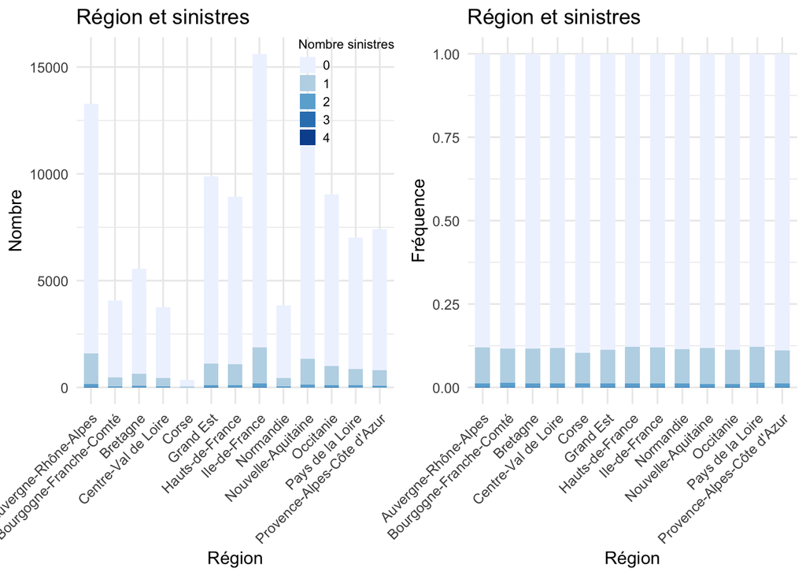

### Statistiques autour du véhicule

La légende des abscisses de certains graphiques se sont pas lisibles mais ces derniers permettent la construction de classes pertinentes.

##### Âge du véhicule

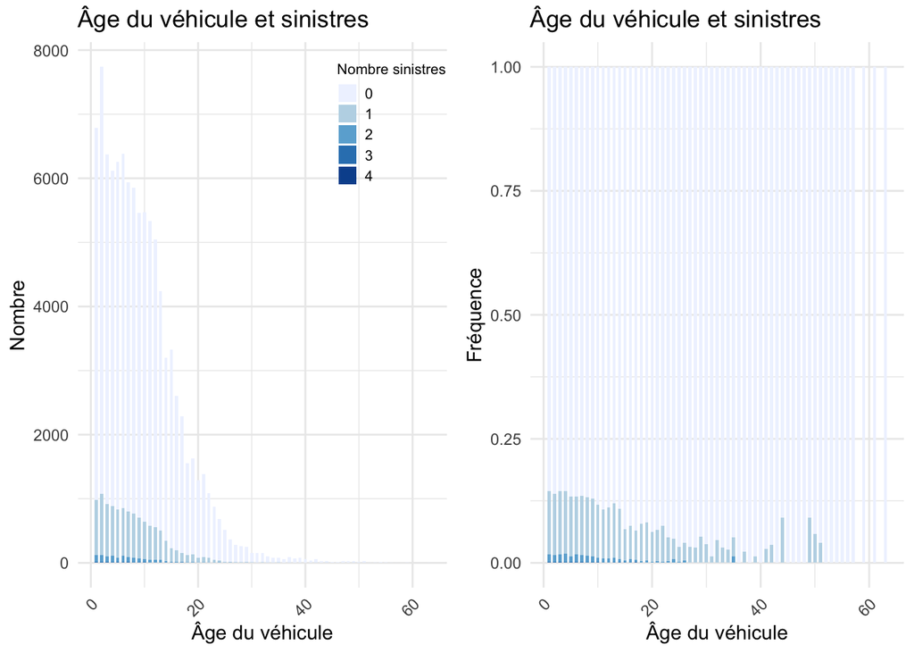

Il est clair que le nombre de sinistre diminue avec l’âge du véhicule.

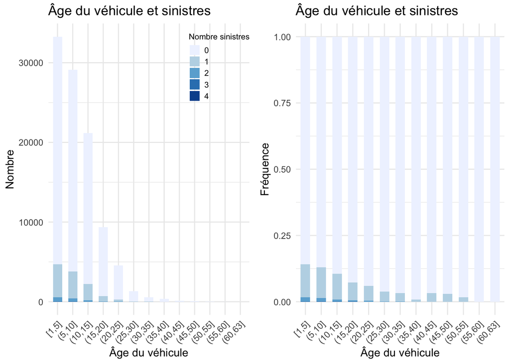

##### Valeur du véhicule

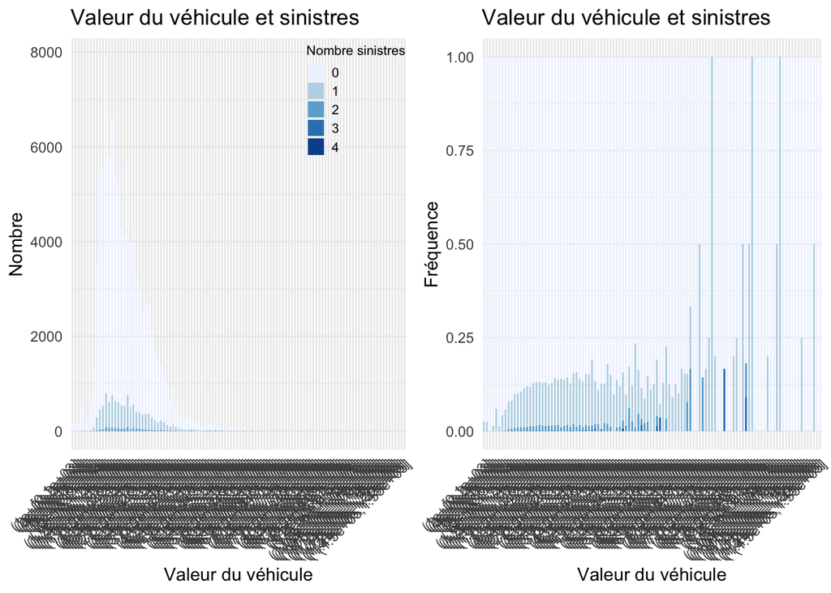

Les classes construites permettent la visualition de l’augmentation de la fréquence avec la valeur de la voiture.

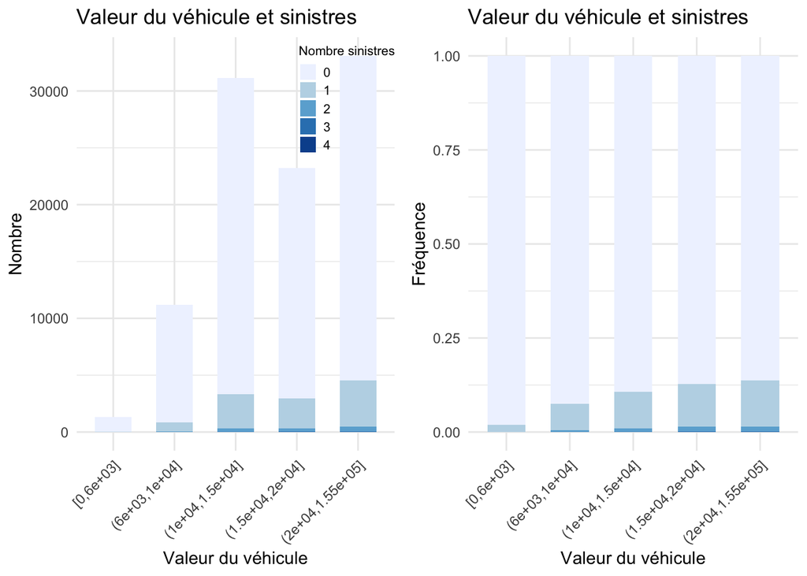

##### Puissance du véhicule

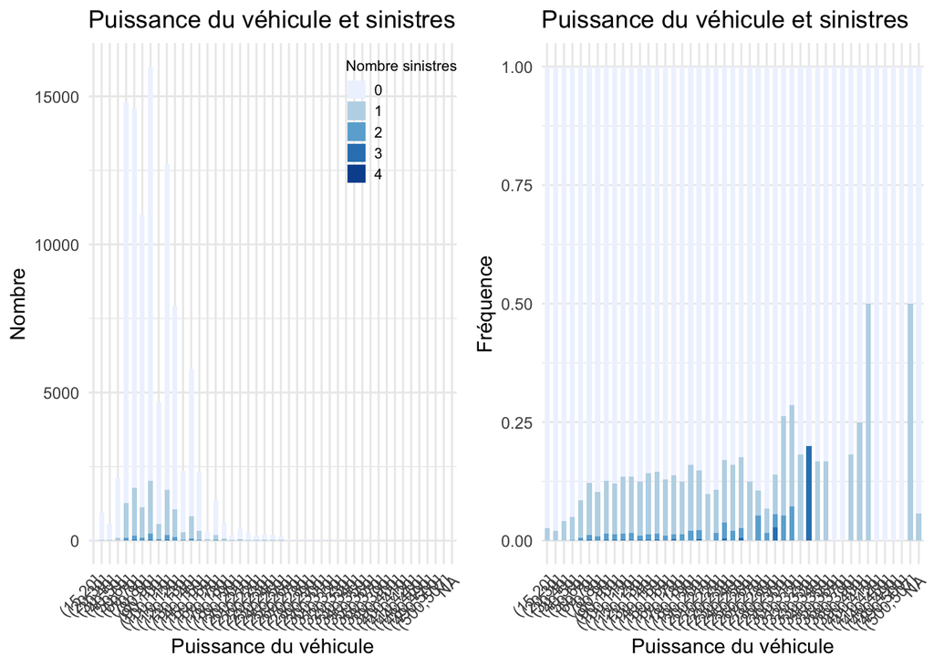

Les classes suivantes sont construites pour la puissance de la voiture.

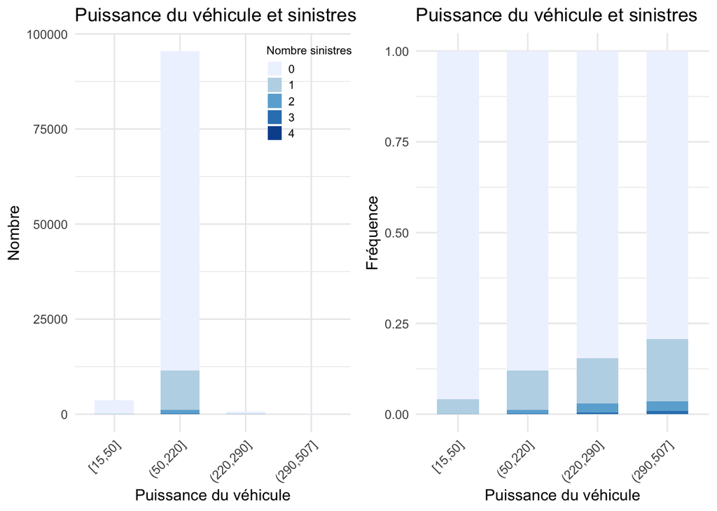

##### Alimentation du véhicule

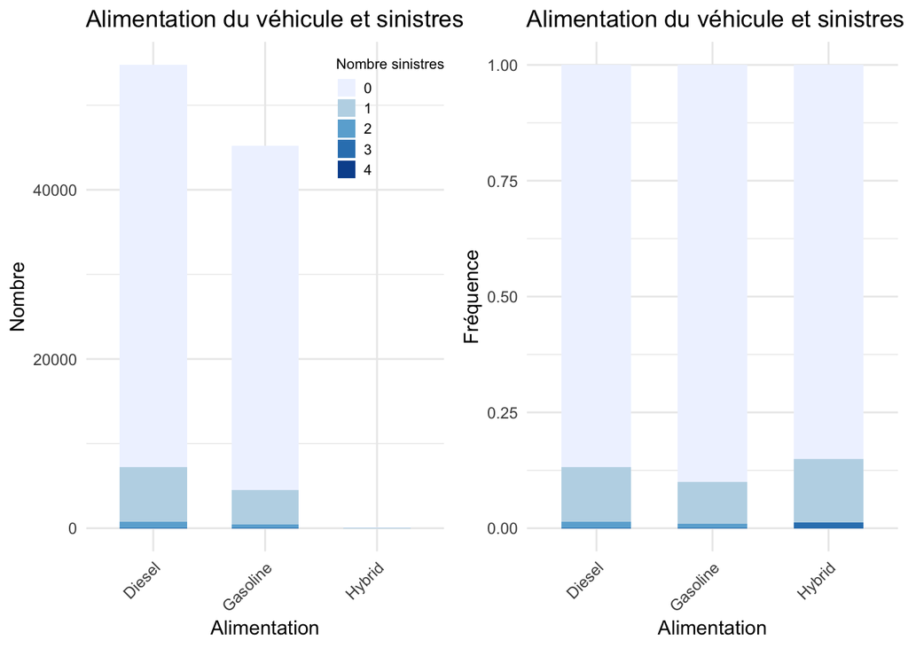

##### Constructeur du véhicule

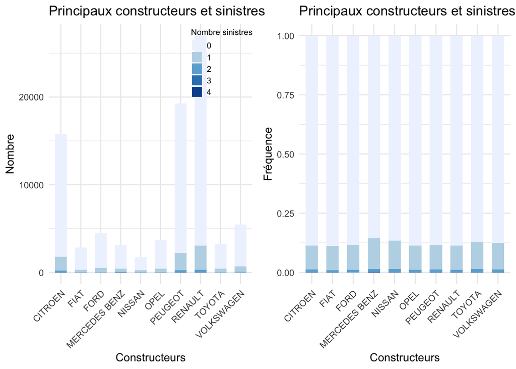

Les constructeurs sont répartis dans différentes classes sous le même format que dans le cours (à l’execption que les véhicules coréens et japonais sont classés dans la catégorie G).

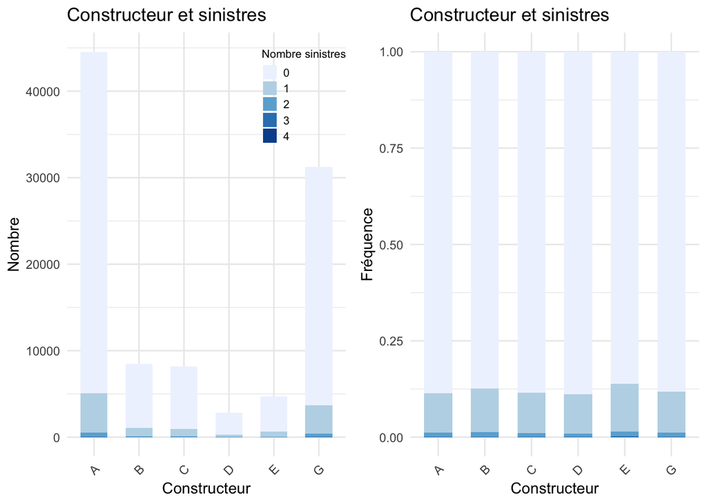